# R Notebook

DS 202 - lab #5: Drunk Driving and Fatal Accidents

Use the User’s manual to find what the columns stand for. The manual can be found at https://crashstats.nhtsa.dot.gov/Api/Public/ViewPublication/812602

Two of the main tables we are going to look at are the accident and the person tables. These data are made available here: accident, and person

Load the two datasets.

```r
acc <- read.csv("https://raw.githubusercontent.com/xdaiISU/ds202materials/master/hwlabs/fars2017/accident.csv", stringsAsFactors = FALSE)
per <- read.csv("https://raw.githubusercontent.com/xdaiISU/ds202materials/master/hwlabs/fars2017/person.csv", stringsAsFactors = FALSE)
library(ggplot2)
library(lubridate)
library(tidyverse)
library(maps)
```

# Question One

Are there some days of the week where more accidents happen than the others (see FARS manual, use variable DAY_WEEK)?

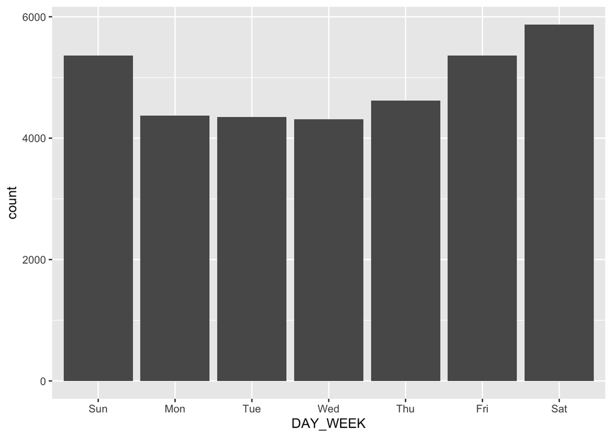

```r
p<-acc%>%
  mutate(DAY_WEEK = wday(`DAY_WEEK`,label=TRUE))%>%
  ggplot(aes(x=`DAY_WEEK`))
p+geom_bar()
```

**Accidents are generally highest during the weekend and peak on Saturdays. The fewest accidents occur on Wednesdays.**

# Question 2

Create a data frame containing the persons who are fatally hurt in the accidents (look up variable INJ_SEV)

```r
per0<-per%>%
  filter(INJ_SEV==4)
head(per0)
```

|  | STATE | ST_CASE | VE_FORMS | VEH_NO | PER_NO | STR_VEH | COUNTY | DAY | MONTH | HOUR | MINUTE | RUR_URB | FUNC_SYS | HARM_EV | MAN_COLL | SCH_BUS | MAKE | MAK_MOD | BODY_TYP | MOD_YEAR | TOW_VEH | SPEC_USE | EMER_USE | ROLLOVER | IMPACT1 | FIRE_EXP | AGE | SEX | PER_TYP | … |
| --- | --- | --- | --- | --- | --- | --- | --- | --- | --- | --- | --- | --- | --- | --- | --- | --- | --- | --- | --- | --- | --- | --- | --- | --- | --- | --- | --- | --- | --- | --- |
| 1 | 1 | 10001 | 1 | 1 | 1 | 0 | 73 | 19 | 2 | 23 | 35 | 2 | 1 | 38 | 0 | 0 | 20 | 20421 | 15 | 2004 | 1 | 0 | 0 | 0 | 12 | 0 | 42 | 1 | 1 | … |
| 2 | 1 | 10002 | 1 | 1 | 1 | 0 | 89 | 14 | 2 | 14 | 59 | 2 | 1 | 1 | 0 | 0 | 37 | 37402 | 14 | 2005 | 0 | 0 | 0 | 9 | 0 | 0 | 43 | 1 | 1 | … |
| 3 | 1 | 10003 | 3 | 2 | 1 | 0 | 101 | 31 | 1 | 20 | 31 | 2 | 1 | 12 | 1 | 0 | 2 | 2404 | 14 | 2003 | 0 | 0 | 0 | 0 | 6 | 0 | 47 | 1 | 1 | … |
| 4 | 1 | 10004 | 1 | 1 | 1 | 0 | 73 | 1 | 1 | 16 | 55 | 2 | 4 | 30 | 0 | 0 | 30 | 30046 | 4 | 2014 | 0 | 0 | 0 | 1 | 11 | 0 | 18 | 1 | 1 | … |
| 5 | 1 | 10005 | 1 | 1 | 1 | 0 | 13 | 1 | 1 | 20 | 0 | 1 | 1 | 35 | 0 | 0 | 12 | 12471 | 34 | 2010 | 0 | 0 | 0 | 1 | 12 | 0 | 67 | 2 | 1 | … |
| 6 | 1 | 10006 | 2 | 1 | 1 | 0 | 49 | 6 | 1 | 18 | 40 | 1 | 1 | 34 | 0 | 0 | 49 | 49032 | 4 | 1997 | 0 | 0 | 0 | 1 | 11 | 0 | 18 | 2 | 1 | … |

# Question 3

Create a data frame containing the most dangerous vehicle make in each state. The number of persons fatally hit in the vehicle make is used to assess the (non-)safety of a make. Make sure to handle the missing values appropriately. (look up variable MAKE)

```r
per1<-per%>%
  na.omit(MAKE)%>%
  group_by(STATE, MAKE)%>%
  rename(`State Code`= STATE)%>%
  summarize(n=n())%>%
  filter(n==max(n))
per1
```

| State Code | MAKE | n |
| --- | --- | --- |
| 1 | 20 | 293 |
| 2 | 20 | 29 |
| 4 | 12 | 305 |
| 5 | 20 | 171 |
| 6 | 49 | 1079 |
| 8 | 12 | 176 |
| 9 | 37 | 63 |
| 10 | 12 | 29 |
| 10 | 37 | 29 |
| 11 | 37 | 13 |

[output cut: 42 more lines]

# Question 4

Create a map, and label each state with the most dangerous vehicle. Discuss the definition of the most dangerous vehicle, and what you find from the map. (Hint: Read the description for the STATE and COUNTY columns in the FARS manual. The state & county codes are Geographic Locator Codes (GLCs) from the General Services Administration’s (GSA) publication. Use readxl::read_xlsx to read in the GLCs.)

[figure not shown]

```r
library(readxl)
states = map_data("state")

textytext<- readxl::read_xlsx("./states.xlsx")%>%
  mutate(`State Name`= tolower(`State Name`)) %>%
  mutate(`State Code`=as.numeric(`State Code`))%>%
  left_join(per1)%>%
  group_by(`State Code`, MAKE)
states1<-states%>%
  group_by(region)%>%
  summarize(avelong=mean(long), avelat=mean(lat), group=median(group))%>%
  left_join(textytext, by=c(region='State Name'))


ggplot(states, aes(x='long', y='lat')) +
  geom_polygon(aes(group = group)) +
  geom_text(aes(x=avelong, y=avelat, label = MAKE), data = states1)
```

# Question 5

Join the accident and person table (work out which variable(s) to use)

```r
baby<-acc %>%
  right_join(per, by='ST_CASE')%>%
  unique()
head(baby)
```

|  | STATE.x | ST_CASE | VE_TOTAL | VE_FORMS.x | PVH_INVL | PEDS | PERNOTMVIT | PERMVIT | PERSONS | COUNTY.x | CITY | DAY.x | MONTH.x | YEAR | DAY_WEEK | HOUR.x | MINUTE.x | NHS | RUR_URB.x | FUNC_SYS.x | RD_OWNER | ROUTE | TWAY_ID | TWAY_ID2 | MILEPT | LATITUDE | LONGITUD | SP_JUR | HARM_EV.x | … |
| --- | --- | --- | --- | --- | --- | --- | --- | --- | --- | --- | --- | --- | --- | --- | --- | --- | --- | --- | --- | --- | --- | --- | --- | --- | --- | --- | --- | --- | --- | --- |
| 1 | 1 | 10001 | 1 | 1 | 0 | 0 | 0 | 1 | 1 | 73 | 330 | 19 | 2 | 2017 | 1 | 23 | 35 | 1 | 2 | 1 | 1 | 1 | I-459 |  | 10 | 33.33566 | -87.00709 | 0 | 38 | … |
| 2 | 1 | 10002 | 1 | 1 | 0 | 0 | 0 | 1 | 1 | 89 | 1730 | 14 | 2 | 2017 | 3 | 14 | 59 | 1 | 2 | 1 | 1 | 1 | I-565 |  | 70 | 34.66153 | -86.78685 | 0 | 1 | … |
| 3 | 1 | 10003 | 3 | 3 | 0 | 0 | 0 | 3 | 3 | 101 | 2130 | 31 | 1 | 2017 | 3 | 20 | 31 | 1 | 2 | 1 | 1 | 1 | I-85 | CHANTILLY PKWY | 100 | 32.36652 | -86.14528 | 0 | 12 | … |
| 4 | 1 | 10003 | 3 | 3 | 0 | 0 | 0 | 3 | 3 | 101 | 2130 | 31 | 1 | 2017 | 3 | 20 | 31 | 1 | 2 | 1 | 1 | 1 | I-85 | CHANTILLY PKWY | 100 | 32.36652 | -86.14528 | 0 | 12 | … |
| 5 | 1 | 10003 | 3 | 3 | 0 | 0 | 0 | 3 | 3 | 101 | 2130 | 31 | 1 | 2017 | 3 | 20 | 31 | 1 | 2 | 1 | 1 | 1 | I-85 | CHANTILLY PKWY | 100 | 32.36652 | -86.14528 | 0 | 12 | … |
| 6 | 1 | 10004 | 1 | 1 | 0 | 0 | 0 | 1 | 1 | 73 | 350 | 1 | 1 | 2017 | 1 | 16 | 55 | 0 | 2 | 4 | 4 | 6 | 20TH ST ENSLEY | AVE I | 0 | 33.51017 | -86.89400 | 0 | 30 | … |

**Handsome baby data frame**

# Question 6

Tally the number of accidents by day of the week (DAY_WEEK), hour of the day (HOUR) and gender (SEX). Visualize the results and explain what you find.

```r
baby0 <- baby %>%
  mutate(SEX = factor(SEX, levels=c(1, 2), labels=c('Male','Female'))) %>%
  na.omit() %>%
  group_by(DAY_WEEK, SEX) %>%
  summarize(`Count of Accidents`=n())
```

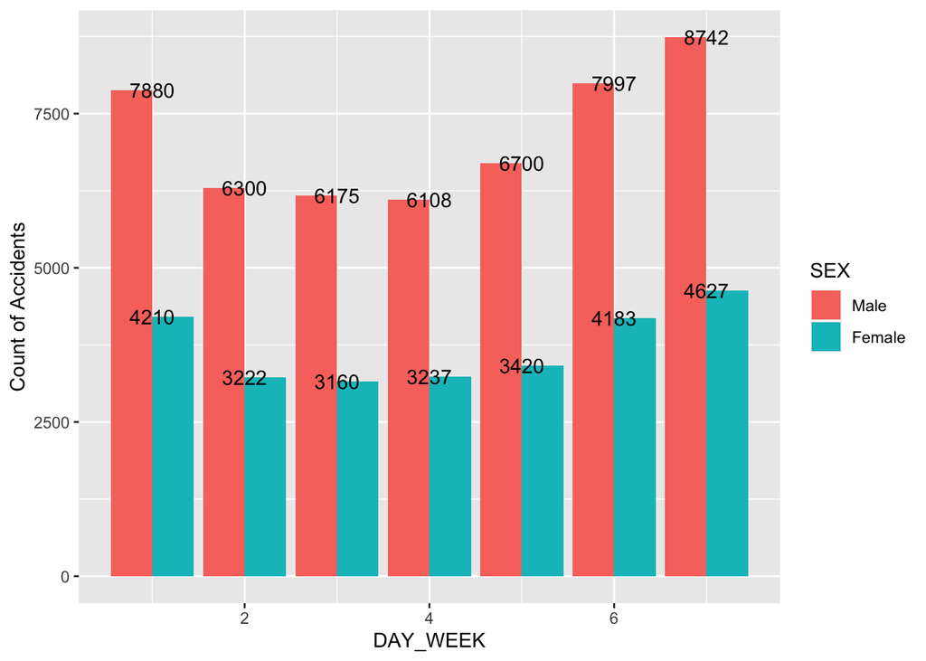

```r
ggplot(baby0, aes(x=DAY_WEEK, y=`Count of Accidents`, fill=SEX, label=`Count of Accidents`)) + geom_bar(stat="identity", position="dodge") + geom_text()
```

**Men are involved in many more accidents than women. Accidents are most frequent for both genders during the weekend.**

```r
baby1<- baby%>%
  mutate(SEX = factor(SEX, levels=c(1, 2), labels=c('Male','Female'))) %>%
  na.omit() %>%
  filter(HOUR.x %in% 1:24)%>%
  group_by(HOUR.x, SEX) %>%
  summarize(`Count of Accidents`=n())
```

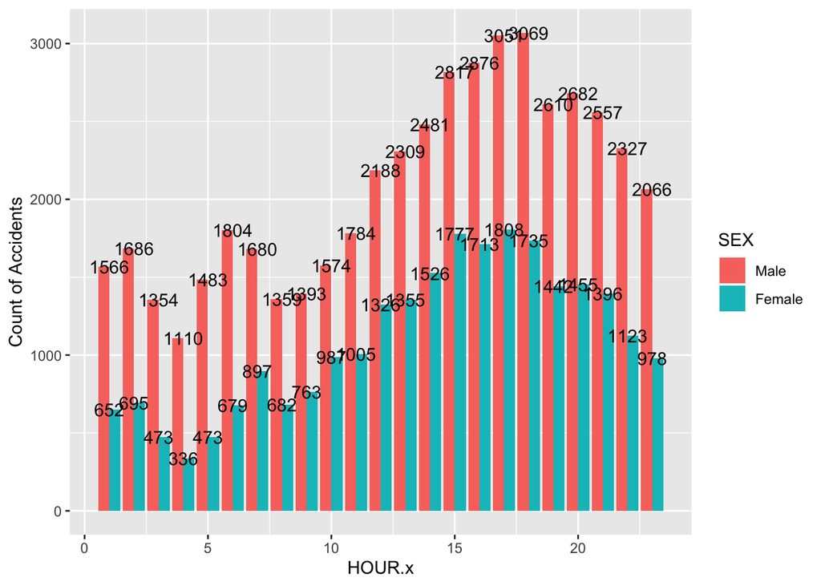

```r
ggplot(baby1, aes(x=HOUR.x, y=`Count of Accidents`, fill=SEX, label=`Count of Accidents`)) + geom_bar(stat="identity", position="dodge") + geom_text()
```

**Men crash more than women during all hours of the day, particularly real early in the morning. Accidents peak for both genders around rush hour.**

# Question 7

Now plot a choropleth map of the number of deaths on a county level. Also explain what you find.

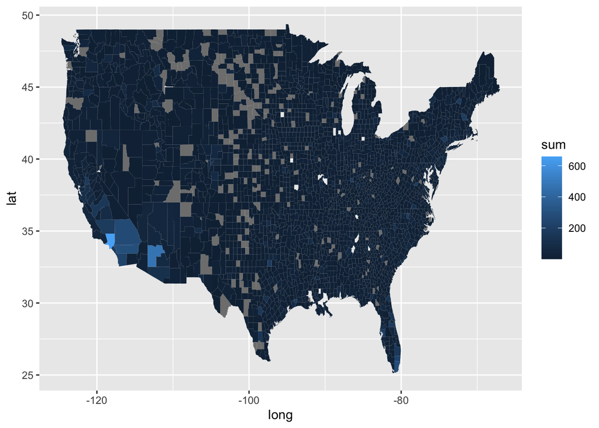

```r
counties = map_data("county")

acc2<-acc%>%
  select(STATE, FATALS, COUNTY)%>%
  filter(FATALS!=0)%>%
  group_by(STATE, COUNTY)%>%
  summarize(sum=sum(FATALS))
zzz<- textytext%>%
  mutate(subregion = tolower(`County Name`), STATE=as.numeric(`State Code`), COUNTY=as.numeric(`County Code`))%>%
  select(subregion, STATE,`COUNTY`)%>%
  left_join(acc2, by=c('STATE','COUNTY'))%>%
  group_by(STATE, COUNTY)%>%
  unique()%>%
  left_join(counties)%>%
  unique()
ggplot(zzz, aes(x=long, y=lat, fill=sum))+geom_polygon(aes(group=group))
```

**The LA Metro generally has the highest number of per county accidents.**

# Question 8

Is summer or winter more dangerous? Does this depend on states? Explore and explain.

```r
#zonked <- textytext%>%
 # mutate(STATE=as.numeric(`State Code`))%>%
  #select(`State Name`, STATE)%>%
  #left_join(acc)%>%
#  filter(FATALS!=0)

#zonked
```

[output not shown]